# Estatística Computacional

Tópico 6

## Funcção de Distribuição Acumulada *empírica*

## FDA empírica

**Definição 1 (FDA empírica.)** A *função de distribuição empírica* é dada por \[ \hat{F}_n(x) = \frac{\sum_{i=1}^{n} I(X_i \leq x)}{n}, \] em que \(I(X_i \leq x) = \begin{cases} 1,& X_i \leq x,\\ 0,& X_i > x. \end{cases}\)

**Teorema 1 (Convergência em probabilidade.)** Seja \(X_1, \dots, X_n \overset{iid}{\sim} F(\cdot)\). Para todo \(x\), temos que

- \(\hat{F}_n(x) \overset{P}{\rightarrow} F(x)\)
- \(E(F_n(x)) = F(x)\)
- \(Var(F_n(x)) = \frac{F(x)\cdot (1 - F(x))}{n}\)
- \(EQM = \frac{F(x)\cdot (1 - F(x))}{n} \rightarrow 0\)

## FDA empírica

```r
fda_empirica <- function(amostra) {
  \(x) seq_along(x) |> map_dbl(\(i) (amostra <= x[i]) |> mean())
}

amostra <- rnorm(100)
fda <- fda_empirica(amostra)
x <- seq(from = -5, to = 5, length.out = 1000)
dados <- tibble(x = x, y = fda(x))

ggplot(dados) +
  theme_minimal() +
  geom_line(aes(x = x, y = y)) +
  labs(x = "X", y = "FDA empírica")
```

## FDA empírica

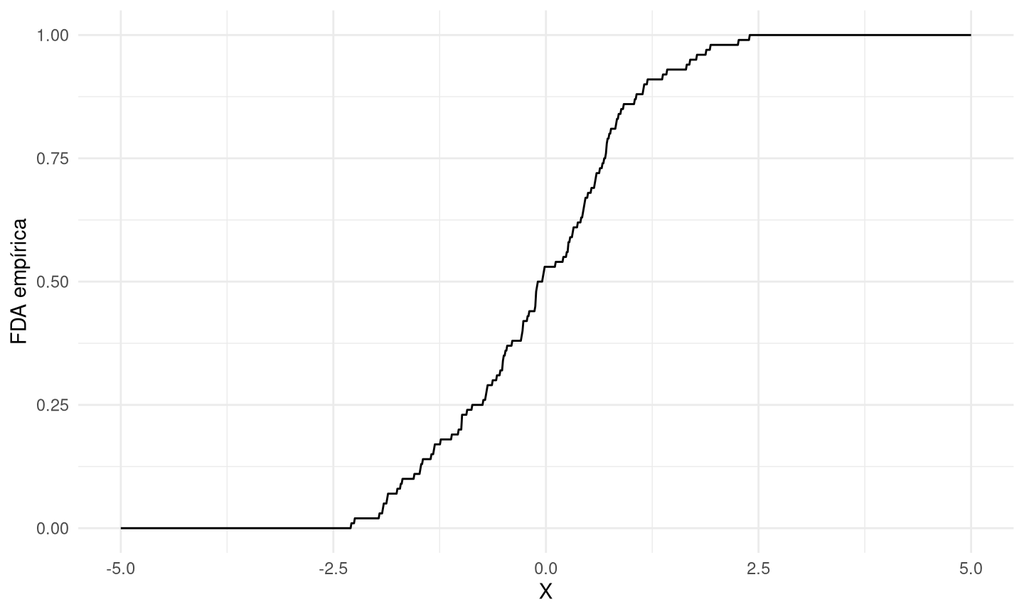

## Desigualdades e convergência

**Teorema 2 (Teorema de Glivenko-Cantelli)** Seja \(X_1, \dots, X_n \overset{idd}{\sim} F(\cdot)\), então \[ \sup_{n} \lvert F_n(x) - F(x) \rvert \overset{a.s.}{\longrightarrow} 0. \]

**Teorema 3 (Desigualdade de Dvoretzky-Kiefer-Wolfowitz.)** Seja \(X_1, \dots, X_n \overset{iid}{\sim} F(\cdot)\), então para \(\epsilon>0\) temos que \[ P(\sup_{x} \lvert F_n(x) - F(x) \rvert > \epsilon) \leq 2^{-2\cdot n \epsilon^2}. \]

## Intervalo de confiança

Note que \[ P(\sup_{x} \lvert F_n(x) - F(x) \rvert > \epsilon) + P(\sup_{x} \lvert F_n(x) - F(x) \rvert \leq \epsilon) = 1 \] e, usando a desigualdade de Dvoretzky-Kiefer-Wolfowitz, temos que \[ \begin{split} P(\sup_{x} \lvert F_n(x) - F(x) \rvert \leq \epsilon) &= 1 - P(\sup_{x} \lvert F_n(x) - F(x) \rvert > \epsilon),\\ &\geq 1 - 2^{-2 \cdot n \epsilon^2},\\ [\sup_{x} \lvert F_n(x) - F(x) \rvert \leq \epsilon] &\subset [\lvert F_n(x) - F(x) \rvert \leq \epsilon], \end{split} \] logo \[ 1 - 2^{2 n \epsilon^2} \leq P(\sup_{x} \lvert F_n(x) - F(x) \rvert \leq \epsilon) \leq P( \lvert F_n(x) - F(x) \rvert \leq \epsilon). \] Para \(n\) fixo e nível de significância \(\alpha\), considere \(1-\alpha = 1 - 2^{2 n \epsilon_n^2}\) e, consequentemente, \(\epsilon_n = \sqrt{\frac{\log_2(\alpha)}{-2n}}\)

## Intervalo de confiança

Para \(\alpha\) e \(n\) fixos, considere \(\epsilon_n = \sqrt{\frac{\log_2(\alpha)}{-2n}}\). Então, o intervalo de confiança para \(F(x)\) é dado por \[ -\epsilon_n + F_n(x) \leq F(x) \leq \epsilon_n + F_n(x), \] ou seja, \[ IC(F(x), 1- \alpha) = \left( \max\left( -\sqrt{\frac{\log_2(\alpha)}{-2n}} + F_n(x);0 \right); \min\left( \sqrt{\frac{\log_2(\alpha)}{-2n}} + F_n(x); 1 \right) \right). \]

## Intervalo de confiança

```r
fda_empirica_2 <- function(amostra, sig_level = 0.05) {
   \(x) {
     Fn <- seq_along(x) |> map_dbl(\(i) (amostra <= x[i]) |> mean())
     en <- sqrt(log2(sig_level) / (-2 * length(amostra)))
     list(est = Fn,
          lower = Fn |> map_dbl(\(Fn) max(Fn - en, 0)),
          upper = Fn |> map_dbl(\(Fn) min(Fn + en, 1)))
   }
}
amostra <- rnorm(100)
fda <- fda_empirica_2(amostra)
x <- seq(from = -5, to = 5, by = 0.01)
y <- fda(x)
dados <- tibble(x = x, est = y$est, lower_ic = y$lower, upper_ci = y$upper,
                fda = pnorm(x))
ggplot(dados, mapping = aes(x = x)) +
  theme_minimal() +
  geom_line(aes(y = est), color = "blue") +
  geom_line(aes(y = fda), color = "red") +
  geom_ribbon(aes(ymin = lower_ic, ymax = upper_ci), alpha = 0.5)
```

## Intervalo de confiança

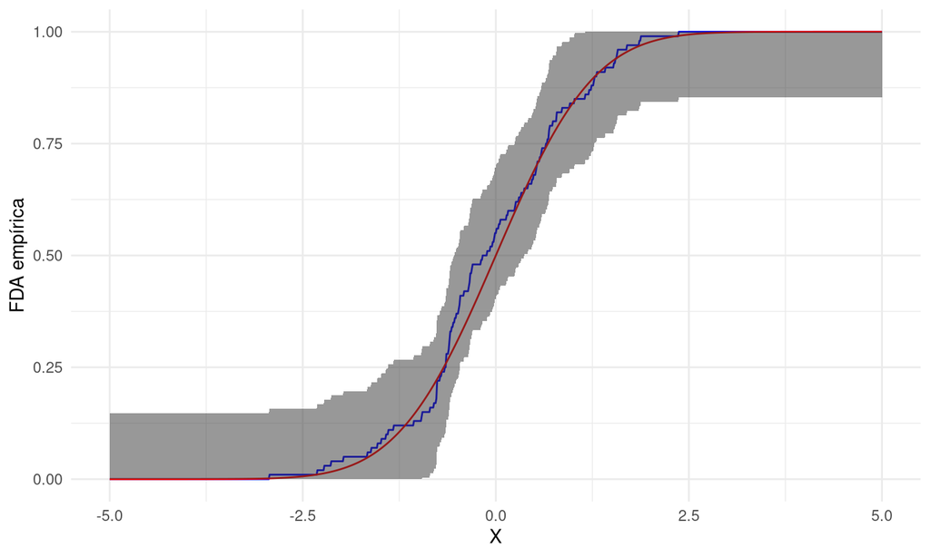

## Funcional estatístico

**Definição 2 (Funcional estatística.)** Funcional estatístico é uma função \(T:P \rightarrow \mathbb{R}\), em que \(P\) é o conjunto das função de distribuição de probabilidade.

**Exemplo 1 (Média e variância.)** Alguns exemplos de funcionais estatísticos:

- **Média:** \(\mu = \int x dF(x)\)
- **Variância:** \(\sigma^2 = \int (x - \mu)^2 dF(x)\)

**Definição 3 (Estimador plug-in)** O estimador *plug-in* de um funcional estatístico \(\theta = T(F)\) é dado por \(\hat{\theta} = T(F_n)\), em que \(F_n\) é a função de distribuição acumulada empírica.

**Definição 4 (Funcional linear)** Se existe uma função \(r:\mathbb{R} \rightarrow \mathbb{R}\) tal que \(T(F) = \int r(x) dF(x)\), em que \(T(F)\) é um funcional estatístico, então \(T(F)\) é chamado de **funcional linear**.

## Funcional estatístico

**Teorema 4** O estimador *plug-in* para um funcional linear dado por \(\theta = T(F) = \int r(x) dF(x)\) é dado por \[ \hat\theta = T(F_n) = \int r(x) dF_n(x) = \frac{1}{n} \sum_{i=1}^{n} r(X_i). \]

## Funcional estatístico

### Exemplos

**Exemplo 2 (Média.)** \(\hat\mu = \int x d_Fn(x)= \frac{1}{n} \sum_{i=1}^{n} X_i\)

```r
amostra <- rnorm(1000)
media_hat <- seq_along(amostra) |>
  map_dbl(\(i) amostra[i] / length(amostra)) |>
  sum()
media_hat
```

```
## [1] 0.03593072
```

**Exemplo 3 (Variância)** \(\hat\sigma^2 = \int (x - \mu)² dF_n(x) = \frac{1}{n} \sum_{i=1}^{n} (X_i - \mu)^2\)

```r
amostra <- rnorm(1000, mean = 1)
var_hat <- seq_along(amostra) |>
  map_dbl(\(i) (amostra[i] - 1)^2 / length(amostra)) |>
  sum()
var_hat
```

```
## [1] 1.04338
```